# Risk Factor Analysis

## Outcome Variable

**Outcome Variable:** whz

## Predictor Variables

**Intervention Variable:** enstunt

**Adjustment Set:**

unadjusted

## Stratifying Variables

The analysis was stratified on these variable(s):

- agecat
- studyid
- country

## Data Summary

| agecat | studyid | country | enstunt | n_cell | n |
| --- | --- | --- | --- | --- | --- |
| Birth | ki0047075b-MAL-ED | BANGLADESH | 0 | 210 | 241 |
| Birth | ki0047075b-MAL-ED | BANGLADESH | 1 | 31 | 241 |
| Birth | ki0047075b-MAL-ED | BRAZIL | 0 | 169 | 183 |
| Birth | ki0047075b-MAL-ED | BRAZIL | 1 | 14 | 183 |
| Birth | ki0047075b-MAL-ED | INDIA | 0 | 173 | 203 |
| Birth | ki0047075b-MAL-ED | INDIA | 1 | 30 | 203 |
| Birth | ki0047075b-MAL-ED | NEPAL | 0 | 154 | 168 |
| Birth | ki0047075b-MAL-ED | NEPAL | 1 | 14 | 168 |
| Birth | ki0047075b-MAL-ED | PERU | 0 | 253 | 279 |
| Birth | ki0047075b-MAL-ED | PERU | 1 | 26 | 279 |
| Birth | ki0047075b-MAL-ED | SOUTH AFRICA | 0 | 232 | 258 |
| Birth | ki0047075b-MAL-ED | SOUTH AFRICA | 1 | 26 | 258 |
| Birth | ki0047075b-MAL-ED | TANZANIA, UNITED REPUBLIC OF | 0 | 105 | 118 |
| Birth | ki0047075b-MAL-ED | TANZANIA, UNITED REPUBLIC OF | 1 | 13 | 118 |
| Birth | ki1000108-CMC-V-BCS-2002 | INDIA | 0 | 77 | 88 |
| Birth | ki1000108-CMC-V-BCS-2002 | INDIA | 1 | 11 | 88 |
| Birth | ki1000108-IRC | INDIA | 0 | 318 | 343 |
| Birth | ki1000108-IRC | INDIA | 1 | 25 | 343 |
| Birth | ki1000109-EE | PAKISTAN | 0 | 0 | 1 |
| Birth | ki1000109-EE | PAKISTAN | 1 | 1 | 1 |
| Birth | ki1000109-ResPak | PAKISTAN | 0 | 5 | 6 |
| Birth | ki1000109-ResPak | PAKISTAN | 1 | 1 | 6 |
| Birth | ki1000304b-SAS-CompFeed | INDIA | 0 | 141 | 166 |
| Birth | ki1000304b-SAS-CompFeed | INDIA | 1 | 25 | 166 |
| Birth | ki1017093-NIH-Birth | BANGLADESH | 0 | 27 | 28 |
| Birth | ki1017093-NIH-Birth | BANGLADESH | 1 | 1 | 28 |
| Birth | ki1017093c-NIH-Crypto | BANGLADESH | 0 | 22 | 23 |
| Birth | ki1017093c-NIH-Crypto | BANGLADESH | 1 | 1 | 23 |
| Birth | ki1101329-Keneba | GAMBIA | 0 | 1347 | 1423 |
| Birth | ki1101329-Keneba | GAMBIA | 1 | 76 | 1423 |

[output cut: 142 more lines]

The following strata were considered:

- agecat: 24 months, studyid: ki0047075b-MAL-ED, country: BANGLADESH
- agecat: 24 months, studyid: ki0047075b-MAL-ED, country: BRAZIL
- agecat: 24 months, studyid: ki0047075b-MAL-ED, country: INDIA
- agecat: 24 months, studyid: ki0047075b-MAL-ED, country: NEPAL
- agecat: 24 months, studyid: ki0047075b-MAL-ED, country: PERU
- agecat: 24 months, studyid: ki0047075b-MAL-ED, country: SOUTH AFRICA
- agecat: 24 months, studyid: ki0047075b-MAL-ED, country: TANZANIA, UNITED REPUBLIC OF
- agecat: 24 months, studyid: ki1000108-CMC-V-BCS-2002, country: INDIA
- agecat: 24 months, studyid: ki1000108-IRC, country: INDIA
- agecat: 24 months, studyid: ki1017093-NIH-Birth, country: BANGLADESH
- agecat: 24 months, studyid: ki1017093b-PROVIDE, country: BANGLADESH
- agecat: 24 months, studyid: ki1017093c-NIH-Crypto, country: BANGLADESH
- agecat: 24 months, studyid: ki1066203-TanzaniaChild2, country: TANZANIA, UNITED REPUBLIC OF
- agecat: 24 months, studyid: ki1101329-Keneba, country: GAMBIA
- agecat: 24 months, studyid: ki1113344-GMS-Nepal, country: NEPAL
- agecat: 24 months, studyid: ki1114097-CMIN, country: BANGLADESH
- agecat: 24 months, studyid: ki1114097-CMIN, country: GUINEA-BISSAU
- agecat: 24 months, studyid: ki1114097-CMIN, country: PERU
- agecat: 24 months, studyid: ki1114097-CONTENT, country: PERU
- agecat: 24 months, studyid: ki1119695-PROBIT, country: BELARUS
- agecat: 24 months, studyid: ki1126311-ZVITAMBO, country: ZIMBABWE
- agecat: 24 months, studyid: ki1135781-COHORTS, country: GUATEMALA
- agecat: 24 months, studyid: ki1135781-COHORTS, country: INDIA
- agecat: 24 months, studyid: ki1135781-COHORTS, country: PHILIPPINES
- agecat: 24 months, studyid: ki1148112-LCNI-5, country: MALAWI
- agecat: 24 months, studyid: kiGH5241-JiVitA-3, country: BANGLADESH
- agecat: 24 months, studyid: kiGH5241-JiVitA-4, country: BANGLADESH
- agecat: 6 months, studyid: ki0047075b-MAL-ED, country: BANGLADESH
- agecat: 6 months, studyid: ki0047075b-MAL-ED, country: BRAZIL
- agecat: 6 months, studyid: ki0047075b-MAL-ED, country: INDIA
- agecat: 6 months, studyid: ki0047075b-MAL-ED, country: NEPAL
- agecat: 6 months, studyid: ki0047075b-MAL-ED, country: PERU
- agecat: 6 months, studyid: ki0047075b-MAL-ED, country: SOUTH AFRICA
- agecat: 6 months, studyid: ki0047075b-MAL-ED, country: TANZANIA, UNITED REPUBLIC OF
- agecat: 6 months, studyid: ki1000108-CMC-V-BCS-2002, country: INDIA
- agecat: 6 months, studyid: ki1000108-IRC, country: INDIA
- agecat: 6 months, studyid: ki1000109-EE, country: PAKISTAN
- agecat: 6 months, studyid: ki1000109-ResPak, country: PAKISTAN
- agecat: 6 months, studyid: ki1000304b-SAS-CompFeed, country: INDIA
- agecat: 6 months, studyid: ki1000304b-SAS-FoodSuppl, country: INDIA
- agecat: 6 months, studyid: ki1017093-NIH-Birth, country: BANGLADESH
- agecat: 6 months, studyid: ki1017093b-PROVIDE, country: BANGLADESH
- agecat: 6 months, studyid: ki1017093c-NIH-Crypto, country: BANGLADESH
- agecat: 6 months, studyid: ki1066203-TanzaniaChild2, country: TANZANIA, UNITED REPUBLIC OF
- agecat: 6 months, studyid: ki1101329-Keneba, country: GAMBIA
- agecat: 6 months, studyid: ki1112895-Guatemala BSC, country: GUATEMALA
- agecat: 6 months, studyid: ki1113344-GMS-Nepal, country: NEPAL
- agecat: 6 months, studyid: ki1114097-CMIN, country: BANGLADESH
- agecat: 6 months, studyid: ki1114097-CMIN, country: BRAZIL
- agecat: 6 months, studyid: ki1114097-CMIN, country: GUINEA-BISSAU
- agecat: 6 months, studyid: ki1114097-CMIN, country: PERU
- agecat: 6 months, studyid: ki1114097-CONTENT, country: PERU
- agecat: 6 months, studyid: ki1119695-PROBIT, country: BELARUS
- agecat: 6 months, studyid: ki1126311-ZVITAMBO, country: ZIMBABWE
- agecat: 6 months, studyid: ki1135781-COHORTS, country: GUATEMALA
- agecat: 6 months, studyid: ki1135781-COHORTS, country: INDIA
- agecat: 6 months, studyid: ki1135781-COHORTS, country: PHILIPPINES
- agecat: 6 months, studyid: ki1148112-LCNI-5, country: MALAWI
- agecat: 6 months, studyid: kiGH5241-JiVitA-3, country: BANGLADESH
- agecat: 6 months, studyid: kiGH5241-JiVitA-4, country: BANGLADESH
- agecat: Birth, studyid: ki0047075b-MAL-ED, country: BANGLADESH
- agecat: Birth, studyid: ki0047075b-MAL-ED, country: BRAZIL
- agecat: Birth, studyid: ki0047075b-MAL-ED, country: INDIA
- agecat: Birth, studyid: ki0047075b-MAL-ED, country: NEPAL
- agecat: Birth, studyid: ki0047075b-MAL-ED, country: PERU
- agecat: Birth, studyid: ki0047075b-MAL-ED, country: SOUTH AFRICA
- agecat: Birth, studyid: ki0047075b-MAL-ED, country: TANZANIA, UNITED REPUBLIC OF
- agecat: Birth, studyid: ki1000108-CMC-V-BCS-2002, country: INDIA
- agecat: Birth, studyid: ki1000108-IRC, country: INDIA
- agecat: Birth, studyid: ki1000109-EE, country: PAKISTAN
- agecat: Birth, studyid: ki1000109-ResPak, country: PAKISTAN
- agecat: Birth, studyid: ki1000304b-SAS-CompFeed, country: INDIA
- agecat: Birth, studyid: ki1017093-NIH-Birth, country: BANGLADESH
- agecat: Birth, studyid: ki1017093c-NIH-Crypto, country: BANGLADESH
- agecat: Birth, studyid: ki1101329-Keneba, country: GAMBIA
- agecat: Birth, studyid: ki1114097-CMIN, country: BANGLADESH
- agecat: Birth, studyid: ki1114097-CMIN, country: BRAZIL
- agecat: Birth, studyid: ki1114097-CMIN, country: PERU
- agecat: Birth, studyid: ki1114097-CONTENT, country: PERU
- agecat: Birth, studyid: ki1119695-PROBIT, country: BELARUS
- agecat: Birth, studyid: ki1126311-ZVITAMBO, country: ZIMBABWE
- agecat: Birth, studyid: ki1135781-COHORTS, country: GUATEMALA
- agecat: Birth, studyid: ki1135781-COHORTS, country: INDIA
- agecat: Birth, studyid: ki1135781-COHORTS, country: PHILIPPINES
- agecat: Birth, studyid: kiGH5241-JiVitA-3, country: BANGLADESH
- agecat: Birth, studyid: kiGH5241-JiVitA-4, country: BANGLADESH

### Dropped Strata

Some strata were dropped due to rare outcomes:

- agecat: Birth, studyid: ki1000109-EE, country: PAKISTAN
- agecat: Birth, studyid: ki1000109-ResPak, country: PAKISTAN
- agecat: Birth, studyid: ki1017093-NIH-Birth, country: BANGLADESH
- agecat: Birth, studyid: ki1017093c-NIH-Crypto, country: BANGLADESH
- agecat: Birth, studyid: ki1114097-CMIN, country: BANGLADESH
- agecat: Birth, studyid: ki1114097-CMIN, country: BRAZIL
- agecat: Birth, studyid: ki1114097-CMIN, country: PERU
- agecat: Birth, studyid: ki1114097-CONTENT, country: PERU
- agecat: 6 months, studyid: ki1114097-CMIN, country: BRAZIL
- agecat: 24 months, studyid: ki1066203-TanzaniaChild2, country: TANZANIA, UNITED REPUBLIC OF

## Methods Detail

We’re interested in the causal parameters $E[Y_a]$ for all values of $a \in \mathcal{A}$. These parameters represent the mean outcome if, possibly contrary to fact, we intervened to set all units to have $A=a$. Under the randomization and positivity assumptions, these are identified by the statistical parameters $\psi_a=E_W[E_{Y|A,W}(Y|A=a,W)]$. In addition, we’re interested in the mean of $Y$, $E[Y]$ under no intervention (the observed mean). We will estimate these parameters by using SuperLearner to fit the relevant likelihood factors – $E_{Y|A,W}(Y|A=a,W)$ and $p(A=a|W)$, and then updating our likelihood fit using a joint TMLE.

For unadjusted analyses ($W=\{\}$), initial likelihoods were estimated using Lrnr_glm to estimate the simple $E(Y|A)$ and Lrnr_mean to estimate $p(A)$. For adjusted analyses, a small library containing Lrnr_glmnet, Lrnr_xgboost, and Lrnr_mean was used.

Having estimated these parameters, we will then use the delta method to estimate relative risks and attributable risks relative to a prespecified baseline level of $A$.

# Results Detail

## Results Plots

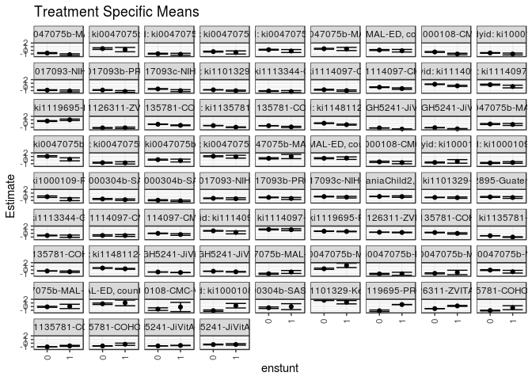

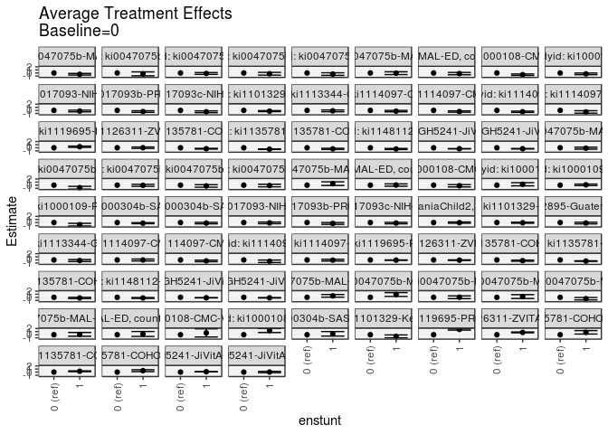

[figure not shown]

## Results Table

### Parameter: TSM

| agecat | studyid | country | intervention_level | baseline_level | estimate | ci_lower | ci_upper |
| --- | --- | --- | --- | --- | --- | --- | --- |
| Birth | ki0047075b-MAL-ED | BANGLADESH | 0 | NA | -1.0246667 | -1.1669927 | -0.8823406 |
| Birth | ki0047075b-MAL-ED | BANGLADESH | 1 | NA | -0.5458065 | -0.9468556 | -0.1447573 |
| Birth | ki0047075b-MAL-ED | BRAZIL | 0 | NA | 0.3340828 | 0.1559318 | 0.5122339 |
| Birth | ki0047075b-MAL-ED | BRAZIL | 1 | NA | 1.2464286 | 0.6538769 | 1.8389803 |
| Birth | ki0047075b-MAL-ED | INDIA | 0 | NA | -1.0730636 | -1.2185220 | -0.9276051 |
| Birth | ki0047075b-MAL-ED | INDIA | 1 | NA | -1.0463333 | -1.4679970 | -0.6246697 |
| Birth | ki0047075b-MAL-ED | NEPAL | 0 | NA | -0.9248052 | -1.0662296 | -0.7833808 |
| Birth | ki0047075b-MAL-ED | NEPAL | 1 | NA | -0.6807143 | -1.2863499 | -0.0750787 |
| Birth | ki0047075b-MAL-ED | PERU | 0 | NA | -0.0322925 | -0.1462353 | 0.0816503 |
| Birth | ki0047075b-MAL-ED | PERU | 1 | NA | -0.4753846 | -0.8475320 | -0.1032372 |
| Birth | ki0047075b-MAL-ED | SOUTH AFRICA | 0 | NA | -0.0678448 | -0.2136271 | 0.0779374 |
| Birth | ki0047075b-MAL-ED | SOUTH AFRICA | 1 | NA | 0.0469231 | -0.5382085 | 0.6320547 |
| Birth | ki0047075b-MAL-ED | TANZANIA, UNITED REPUBLIC OF | 0 | NA | 0.7666667 | 0.5678319 | 0.9655014 |
| Birth | ki0047075b-MAL-ED | TANZANIA, UNITED REPUBLIC OF | 1 | NA | 1.0076923 | 0.2312347 | 1.7841499 |
| Birth | ki1000108-CMC-V-BCS-2002 | INDIA | 0 | NA | -0.7000000 | -1.0503498 | -0.3496502 |
| Birth | ki1000108-CMC-V-BCS-2002 | INDIA | 1 | NA | -0.1200000 | -1.3823136 | 1.1423136 |
| Birth | ki1000108-IRC | INDIA | 0 | NA | -1.1089937 | -1.3001351 | -0.9178523 |
| Birth | ki1000108-IRC | INDIA | 1 | NA | 0.2412000 | -0.3840623 | 0.8664623 |
| Birth | ki1000304b-SAS-CompFeed | INDIA | 0 | NA | -0.3134752 | -0.5218974 | -0.1050530 |
| Birth | ki1000304b-SAS-CompFeed | INDIA | 1 | NA | -0.0232000 | -0.8308802 | 0.7844802 |
| Birth | ki1101329-Keneba | GAMBIA | 0 | NA | 1.7324350 | 1.6491712 | 1.8156989 |
| Birth | ki1101329-Keneba | GAMBIA | 1 | NA | 1.1928947 | 0.7345057 | 1.6512837 |
| Birth | ki1119695-PROBIT | BELARUS | 0 | NA | -1.1495528 | -1.3637971 | -0.9353086 |
| Birth | ki1119695-PROBIT | BELARUS | 1 | NA | 0.5550000 | 0.5276122 | 0.5823878 |
| Birth | ki1126311-ZVITAMBO | ZIMBABWE | 0 | NA | -0.5547391 | -0.5808352 | -0.5286430 |
| Birth | ki1126311-ZVITAMBO | ZIMBABWE | 1 | NA | 0.1864638 | 0.0543136 | 0.3186139 |
| Birth | ki1135781-COHORTS | GUATEMALA | 0 | NA | -1.0868716 | -1.1891249 | -0.9846183 |
| Birth | ki1135781-COHORTS | GUATEMALA | 1 | NA | -0.3079167 | -0.8560815 | 0.2402482 |
| Birth | ki1135781-COHORTS | INDIA | 0 | NA | -1.0012610 | -1.0317045 | -0.9708174 |
| Birth | ki1135781-COHORTS | INDIA | 1 | NA | -0.7321053 | -0.8664813 | -0.5977292 |

[output cut: 122 more lines]

### Parameter: E(Y)

| agecat | studyid | country | intervention_level | baseline_level | estimate | ci_lower | ci_upper |
| --- | --- | --- | --- | --- | --- | --- | --- |
| Birth | ki0047075b-MAL-ED | BANGLADESH | NA | NA | -0.9630705 | -1.0989132 | -0.8272278 |
| Birth | ki0047075b-MAL-ED | BRAZIL | NA | NA | 0.4038798 | 0.2296279 | 0.5781316 |
| Birth | ki0047075b-MAL-ED | INDIA | NA | NA | -1.0691133 | -1.2078629 | -0.9303637 |
| Birth | ki0047075b-MAL-ED | NEPAL | NA | NA | -0.9044643 | -1.0439568 | -0.7649718 |
| Birth | ki0047075b-MAL-ED | PERU | NA | NA | -0.0735842 | -0.1836203 | 0.0364518 |
| Birth | ki0047075b-MAL-ED | SOUTH AFRICA | NA | NA | -0.0562791 | -0.2000837 | 0.0875255 |
| Birth | ki0047075b-MAL-ED | TANZANIA, UNITED REPUBLIC OF | NA | NA | 0.7932203 | 0.5962220 | 0.9902187 |
| Birth | ki1000108-CMC-V-BCS-2002 | INDIA | NA | NA | -0.6275000 | -0.9746292 | -0.2803708 |
| Birth | ki1000108-IRC | INDIA | NA | NA | -1.0105831 | -1.1973019 | -0.8238643 |
| Birth | ki1000304b-SAS-CompFeed | INDIA | NA | NA | -0.2697590 | -0.5399211 | 0.0004030 |
| Birth | ki1101329-Keneba | GAMBIA | NA | NA | 1.7036191 | 1.6208471 | 1.7863911 |
| Birth | ki1119695-PROBIT | BELARUS | NA | NA | -1.1463469 | -1.3562674 | -0.9364264 |
| Birth | ki1126311-ZVITAMBO | ZIMBABWE | NA | NA | -0.5151425 | -0.5409938 | -0.4892911 |
| Birth | ki1135781-COHORTS | GUATEMALA | NA | NA | -1.0621429 | -1.1631387 | -0.9611471 |
| Birth | ki1135781-COHORTS | INDIA | NA | NA | -0.9847457 | -1.0145305 | -0.9549609 |
| Birth | ki1135781-COHORTS | PHILIPPINES | NA | NA | -0.7427251 | -0.7890855 | -0.6963647 |
| Birth | kiGH5241-JiVitA-3 | BANGLADESH | NA | NA | -0.7240996 | -0.7439385 | -0.7042607 |
| Birth | kiGH5241-JiVitA-4 | BANGLADESH | NA | NA | -0.3683163 | -0.4490504 | -0.2875821 |
| 6 months | ki0047075b-MAL-ED | BANGLADESH | NA | NA | -0.1397960 | -0.2688682 | -0.0107238 |
| 6 months | ki0047075b-MAL-ED | BRAZIL | NA | NA | 0.9717225 | 0.8073791 | 1.1360658 |
| 6 months | ki0047075b-MAL-ED | INDIA | NA | NA | -0.7033969 | -0.8285284 | -0.5782654 |
| 6 months | ki0047075b-MAL-ED | NEPAL | NA | NA | 0.1110452 | -0.0202712 | 0.2423616 |
| 6 months | ki0047075b-MAL-ED | PERU | NA | NA | 1.0543956 | 0.9326967 | 1.1760945 |
| 6 months | ki0047075b-MAL-ED | SOUTH AFRICA | NA | NA | 0.5420735 | 0.3899459 | 0.6942011 |
| 6 months | ki0047075b-MAL-ED | TANZANIA, UNITED REPUBLIC OF | NA | NA | 0.5170513 | 0.3872178 | 0.6468847 |
| 6 months | ki1000108-CMC-V-BCS-2002 | INDIA | NA | NA | -0.5026766 | -0.6536848 | -0.3516685 |
| 6 months | ki1000108-IRC | INDIA | NA | NA | -0.5989297 | -0.7344491 | -0.4634104 |
| 6 months | ki1000109-EE | PAKISTAN | NA | NA | -0.7212766 | -0.8346857 | -0.6078675 |
| 6 months | ki1000109-ResPak | PAKISTAN | NA | NA | -0.1683617 | -0.3528233 | 0.0160999 |
| 6 months | ki1000304b-SAS-CompFeed | INDIA | NA | NA | -0.6657084 | -0.8024377 | -0.5289791 |
| 6 months | ki1000304b-SAS-FoodSuppl | INDIA | NA | NA | -1.0121579 | -1.1280429 | -0.8962729 |
| 6 months | ki1017093-NIH-Birth | BANGLADESH | NA | NA | -0.4389101 | -0.5279432 | -0.3498771 |
| 6 months | ki1017093b-PROVIDE | BANGLADESH | NA | NA | -0.2083706 | -0.2927992 | -0.1239419 |
| 6 months | ki1017093c-NIH-Crypto | BANGLADESH | NA | NA | 0.0297622 | -0.0491685 | 0.1086930 |
| 6 months | ki1066203-TanzaniaChild2 | TANZANIA, UNITED REPUBLIC OF | NA | NA | 0.0809332 | 0.0282644 | 0.1336020 |
| 6 months | ki1101329-Keneba | GAMBIA | NA | NA | -0.1846223 | -0.2354964 | -0.1337483 |
| 6 months | ki1112895-Guatemala BSC | GUATEMALA | NA | NA | -0.0840134 | -0.1945572 | 0.0265305 |
| 6 months | ki1113344-GMS-Nepal | NEPAL | NA | NA | -0.6047987 | -0.6909649 | -0.5186325 |
| 6 months | ki1114097-CMIN | BANGLADESH | NA | NA | -0.5780453 | -0.7226627 | -0.4334279 |
| 6 months | ki1114097-CMIN | GUINEA-BISSAU | NA | NA | -0.0418080 | -0.1199942 | 0.0363782 |
| 6 months | ki1114097-CMIN | PERU | NA | NA | 0.6721017 | 0.5829735 | 0.7612299 |
| 6 months | ki1114097-CONTENT | PERU | NA | NA | 1.0684318 | 0.9515274 | 1.1853362 |
| 6 months | ki1119695-PROBIT | BELARUS | NA | NA | 0.5789633 | 0.5190130 | 0.6389137 |
| 6 months | ki1126311-ZVITAMBO | ZIMBABWE | NA | NA | 0.3047138 | 0.2786437 | 0.3307839 |
| 6 months | ki1135781-COHORTS | GUATEMALA | NA | NA | 0.1940810 | 0.1226351 | 0.2655269 |
| 6 months | ki1135781-COHORTS | INDIA | NA | NA | -0.6908803 | -0.7184601 | -0.6633005 |
| 6 months | ki1135781-COHORTS | PHILIPPINES | NA | NA | -0.2938433 | -0.3352064 | -0.2524802 |
| 6 months | ki1148112-LCNI-5 | MALAWI | NA | NA | 0.4499285 | 0.3788279 | 0.5210291 |
| 6 months | kiGH5241-JiVitA-3 | BANGLADESH | NA | NA | -0.5935161 | -0.6130518 | -0.5739805 |
| 6 months | kiGH5241-JiVitA-4 | BANGLADESH | NA | NA | -0.3898055 | -0.4270507 | -0.3525603 |
| 24 months | ki0047075b-MAL-ED | BANGLADESH | NA | NA | -0.8208255 | -0.9429246 | -0.6987264 |
| 24 months | ki0047075b-MAL-ED | BRAZIL | NA | NA | 0.4466272 | 0.2416144 | 0.6516401 |
| 24 months | ki0047075b-MAL-ED | INDIA | NA | NA | -0.9522907 | -1.0676596 | -0.8369219 |
| 24 months | ki0047075b-MAL-ED | NEPAL | NA | NA | -0.3764474 | -0.4898516 | -0.2630431 |
| 24 months | ki0047075b-MAL-ED | PERU | NA | NA | 0.1199005 | -0.0000331 | 0.2398341 |
| 24 months | ki0047075b-MAL-ED | SOUTH AFRICA | NA | NA | 0.4267017 | 0.3074751 | 0.5459283 |
| 24 months | ki0047075b-MAL-ED | TANZANIA, UNITED REPUBLIC OF | NA | NA | 0.0500935 | -0.0748234 | 0.1750103 |
| 24 months | ki1000108-CMC-V-BCS-2002 | INDIA | NA | NA | -0.5571505 | -0.6585247 | -0.4557763 |
| 24 months | ki1000108-IRC | INDIA | NA | NA | -0.7458150 | -0.8368180 | -0.6548120 |
| 24 months | ki1017093-NIH-Birth | BANGLADESH | NA | NA | -0.9115790 | -1.0095022 | -0.8136559 |
| 24 months | ki1017093b-PROVIDE | BANGLADESH | NA | NA | -0.8879412 | -0.9708680 | -0.8050144 |
| 24 months | ki1017093c-NIH-Crypto | BANGLADESH | NA | NA | -0.6103502 | -0.7050157 | -0.5156847 |
| 24 months | ki1101329-Keneba | GAMBIA | NA | NA | -0.8099290 | -0.8570608 | -0.7627972 |
| 24 months | ki1113344-GMS-Nepal | NEPAL | NA | NA | -1.1315863 | -1.2192240 | -1.0439487 |
| 24 months | ki1114097-CMIN | BANGLADESH | NA | NA | -0.8535391 | -0.9644236 | -0.7426546 |
| 24 months | ki1114097-CMIN | GUINEA-BISSAU | NA | NA | -0.1442438 | -0.2323415 | -0.0561461 |
| 24 months | ki1114097-CMIN | PERU | NA | NA | 0.6477778 | 0.5676685 | 0.7278870 |
| 24 months | ki1114097-CONTENT | PERU | NA | NA | 0.5668293 | 0.4302437 | 0.7034148 |
| 24 months | ki1119695-PROBIT | BELARUS | NA | NA | 0.6863435 | 0.5745700 | 0.7981170 |
| 24 months | ki1126311-ZVITAMBO | ZIMBABWE | NA | NA | -1.1809929 | -1.2809380 | -1.0810478 |
| 24 months | ki1135781-COHORTS | GUATEMALA | NA | NA | -0.2815804 | -0.3354498 | -0.2277110 |
| 24 months | ki1135781-COHORTS | INDIA | NA | NA | -0.6073238 | -0.6354743 | -0.5791732 |
| 24 months | ki1135781-COHORTS | PHILIPPINES | NA | NA | -0.6099592 | -0.6467541 | -0.5731643 |
| 24 months | ki1148112-LCNI-5 | MALAWI | NA | NA | -0.0478508 | -0.1297321 | 0.0340305 |
| 24 months | kiGH5241-JiVitA-3 | BANGLADESH | NA | NA | -1.2978031 | -1.3210763 | -1.2745298 |
| 24 months | kiGH5241-JiVitA-4 | BANGLADESH | NA | NA | -1.2231088 | -1.2549632 | -1.1912543 |

### Parameter: ATE

| agecat | studyid | country | intervention_level | baseline_level | estimate | ci_lower | ci_upper |
| --- | --- | --- | --- | --- | --- | --- | --- |
| Birth | ki0047075b-MAL-ED | BANGLADESH | 0 | 0 | 0.0000000 | 0.0000000 | 0.0000000 |
| Birth | ki0047075b-MAL-ED | BANGLADESH | 1 | 0 | 0.4788602 | 0.0533051 | 0.9044153 |
| Birth | ki0047075b-MAL-ED | BRAZIL | 0 | 0 | 0.0000000 | 0.0000000 | 0.0000000 |
| Birth | ki0047075b-MAL-ED | BRAZIL | 1 | 0 | 0.9123457 | 0.2935927 | 1.5310988 |
| Birth | ki0047075b-MAL-ED | INDIA | 0 | 0 | 0.0000000 | 0.0000000 | 0.0000000 |
| Birth | ki0047075b-MAL-ED | INDIA | 1 | 0 | 0.0267303 | -0.4193173 | 0.4727778 |
| Birth | ki0047075b-MAL-ED | NEPAL | 0 | 0 | 0.0000000 | 0.0000000 | 0.0000000 |
| Birth | ki0047075b-MAL-ED | NEPAL | 1 | 0 | 0.2440909 | -0.3778378 | 0.8660196 |
| Birth | ki0047075b-MAL-ED | PERU | 0 | 0 | 0.0000000 | 0.0000000 | 0.0000000 |
| Birth | ki0047075b-MAL-ED | PERU | 1 | 0 | -0.4430921 | -0.8322921 | -0.0538921 |
| Birth | ki0047075b-MAL-ED | SOUTH AFRICA | 0 | 0 | 0.0000000 | 0.0000000 | 0.0000000 |
| Birth | ki0047075b-MAL-ED | SOUTH AFRICA | 1 | 0 | 0.1147679 | -0.4882507 | 0.7177865 |
| Birth | ki0047075b-MAL-ED | TANZANIA, UNITED REPUBLIC OF | 0 | 0 | 0.0000000 | 0.0000000 | 0.0000000 |
| Birth | ki0047075b-MAL-ED | TANZANIA, UNITED REPUBLIC OF | 1 | 0 | 0.2410256 | -0.5604864 | 1.0425377 |
| Birth | ki1000108-CMC-V-BCS-2002 | INDIA | 0 | 0 | 0.0000000 | 0.0000000 | 0.0000000 |
| Birth | ki1000108-CMC-V-BCS-2002 | INDIA | 1 | 0 | 0.5800000 | -0.7300307 | 1.8900307 |
| Birth | ki1000108-IRC | INDIA | 0 | 0 | 0.0000000 | 0.0000000 | 0.0000000 |
| Birth | ki1000108-IRC | INDIA | 1 | 0 | 1.3501937 | 0.6963680 | 2.0040194 |
| Birth | ki1000304b-SAS-CompFeed | INDIA | 0 | 0 | 0.0000000 | 0.0000000 | 0.0000000 |
| Birth | ki1000304b-SAS-CompFeed | INDIA | 1 | 0 | 0.2902752 | -0.4377292 | 1.0182795 |
| Birth | ki1101329-Keneba | GAMBIA | 0 | 0 | 0.0000000 | 0.0000000 | 0.0000000 |
| Birth | ki1101329-Keneba | GAMBIA | 1 | 0 | -0.5395403 | -1.0054301 | -0.0736505 |
| Birth | ki1119695-PROBIT | BELARUS | 0 | 0 | 0.0000000 | 0.0000000 | 0.0000000 |
| Birth | ki1119695-PROBIT | BELARUS | 1 | 0 | 1.7045528 | 1.4868144 | 1.9222912 |
| Birth | ki1126311-ZVITAMBO | ZIMBABWE | 0 | 0 | 0.0000000 | 0.0000000 | 0.0000000 |
| Birth | ki1126311-ZVITAMBO | ZIMBABWE | 1 | 0 | 0.7412028 | 0.6065007 | 0.8759050 |
| Birth | ki1135781-COHORTS | GUATEMALA | 0 | 0 | 0.0000000 | 0.0000000 | 0.0000000 |
| Birth | ki1135781-COHORTS | GUATEMALA | 1 | 0 | 0.7789549 | 0.2213345 | 1.3365753 |
| Birth | ki1135781-COHORTS | INDIA | 0 | 0 | 0.0000000 | 0.0000000 | 0.0000000 |
| Birth | ki1135781-COHORTS | INDIA | 1 | 0 | 0.2691557 | 0.1313743 | 0.4069371 |

[output cut: 122 more lines]

### Parameter: PAR

| agecat | studyid | country | intervention_level | baseline_level | estimate | ci_lower | ci_upper |
| --- | --- | --- | --- | --- | --- | --- | --- |
| Birth | ki0047075b-MAL-ED | BANGLADESH | 0 | NA | 0.0615961 | 0.0032198 | 0.1199724 |
| Birth | ki0047075b-MAL-ED | BRAZIL | 0 | NA | 0.0697969 | 0.0107888 | 0.1288051 |
| Birth | ki0047075b-MAL-ED | INDIA | 0 | NA | 0.0039503 | -0.0619810 | 0.0698816 |
| Birth | ki0047075b-MAL-ED | NEPAL | 0 | NA | 0.0203409 | -0.0324868 | 0.0731687 |
| Birth | ki0047075b-MAL-ED | PERU | 0 | NA | -0.0412917 | -0.0805949 | -0.0019886 |
| Birth | ki0047075b-MAL-ED | SOUTH AFRICA | 0 | NA | 0.0115658 | -0.0493502 | 0.0724817 |
| Birth | ki0047075b-MAL-ED | TANZANIA, UNITED REPUBLIC OF | 0 | NA | 0.0265537 | -0.0628010 | 0.1159084 |
| Birth | ki1000108-CMC-V-BCS-2002 | INDIA | 0 | NA | 0.0725000 | -0.0961414 | 0.2411414 |
| Birth | ki1000108-IRC | INDIA | 0 | NA | 0.0984106 | 0.0379566 | 0.1588647 |
| Birth | ki1000304b-SAS-CompFeed | INDIA | 0 | NA | 0.0437161 | -0.0772467 | 0.1646789 |
| Birth | ki1101329-Keneba | GAMBIA | 0 | NA | -0.0288159 | -0.0544848 | -0.0031471 |
| Birth | ki1119695-PROBIT | BELARUS | 0 | NA | 0.0032059 | -0.0016187 | 0.0080305 |
| Birth | ki1126311-ZVITAMBO | ZIMBABWE | 0 | NA | 0.0395966 | 0.0318476 | 0.0473456 |
| Birth | ki1135781-COHORTS | GUATEMALA | 0 | NA | 0.0247287 | 0.0045231 | 0.0449343 |
| Birth | ki1135781-COHORTS | INDIA | 0 | NA | 0.0165153 | 0.0079093 | 0.0251212 |
| Birth | ki1135781-COHORTS | PHILIPPINES | 0 | NA | 0.0138622 | 0.0043208 | 0.0234036 |
| Birth | kiGH5241-JiVitA-3 | BANGLADESH | 0 | NA | 0.0190095 | 0.0115374 | 0.0264816 |
| Birth | kiGH5241-JiVitA-4 | BANGLADESH | 0 | NA | 0.0033011 | -0.0311258 | 0.0377280 |
| 6 months | ki0047075b-MAL-ED | BANGLADESH | 0 | NA | -0.0201632 | -0.0712053 | 0.0308790 |
| 6 months | ki0047075b-MAL-ED | BRAZIL | 0 | NA | -0.0830736 | -0.1391793 | -0.0269679 |
| 6 months | ki0047075b-MAL-ED | INDIA | 0 | NA | -0.0086761 | -0.0642307 | 0.0468786 |
| 6 months | ki0047075b-MAL-ED | NEPAL | 0 | NA | -0.0286278 | -0.0764363 | 0.0191806 |
| 6 months | ki0047075b-MAL-ED | PERU | 0 | NA | -0.0152697 | -0.0667143 | 0.0361750 |
| 6 months | ki0047075b-MAL-ED | SOUTH AFRICA | 0 | NA | 0.0481943 | -0.0127797 | 0.1091683 |
| 6 months | ki0047075b-MAL-ED | TANZANIA, UNITED REPUBLIC OF | 0 | NA | 0.0060978 | -0.0526191 | 0.0648146 |
| 6 months | ki1000108-CMC-V-BCS-2002 | INDIA | 0 | NA | -0.0377503 | -0.1138691 | 0.0383684 |
| 6 months | ki1000108-IRC | INDIA | 0 | NA | 0.0345054 | -0.0259191 | 0.0949300 |
| 6 months | ki1000109-EE | PAKISTAN | 0 | NA | 0.0388657 | -0.0475042 | 0.1252355 |
| 6 months | ki1000109-ResPak | PAKISTAN | 0 | NA | -0.1807124 | -0.3012690 | -0.0601558 |
| 6 months | ki1000304b-SAS-CompFeed | INDIA | 0 | NA | -0.0545268 | -0.0998749 | -0.0091787 |
| 6 months | ki1000304b-SAS-FoodSuppl | INDIA | 0 | NA | -0.0676751 | -0.1606440 | 0.0252938 |
| 6 months | ki1017093-NIH-Birth | BANGLADESH | 0 | NA | -0.0180546 | -0.0608488 | 0.0247395 |
| 6 months | ki1017093b-PROVIDE | BANGLADESH | 0 | NA | -0.0294402 | -0.0605363 | 0.0016560 |
| 6 months | ki1017093c-NIH-Crypto | BANGLADESH | 0 | NA | -0.0240387 | -0.0585690 | 0.0104915 |
| 6 months | ki1066203-TanzaniaChild2 | TANZANIA, UNITED REPUBLIC OF | 0 | NA | -0.0022489 | -0.0167364 | 0.0122386 |
| 6 months | ki1101329-Keneba | GAMBIA | 0 | NA | -0.0057356 | -0.0229389 | 0.0114676 |
| 6 months | ki1112895-Guatemala BSC | GUATEMALA | 0 | NA | -0.0381362 | -0.1019447 | 0.0256724 |
| 6 months | ki1113344-GMS-Nepal | NEPAL | 0 | NA | -0.0205097 | -0.0545833 | 0.0135639 |
| 6 months | ki1114097-CMIN | BANGLADESH | 0 | NA | -0.0070077 | -0.1230520 | 0.1090365 |
| 6 months | ki1114097-CMIN | GUINEA-BISSAU | 0 | NA | -0.0373546 | -0.0674875 | -0.0072218 |
| 6 months | ki1114097-CMIN | PERU | 0 | NA | -0.0218746 | -0.0435250 | -0.0002242 |
| 6 months | ki1114097-CONTENT | PERU | 0 | NA | -0.0055395 | -0.0297876 | 0.0187087 |
| 6 months | ki1119695-PROBIT | BELARUS | 0 | NA | -0.0005132 | -0.0024629 | 0.0014364 |
| 6 months | ki1126311-ZVITAMBO | ZIMBABWE | 0 | NA | -0.0066741 | -0.0158034 | 0.0024552 |
| 6 months | ki1135781-COHORTS | GUATEMALA | 0 | NA | -0.0378226 | -0.0703559 | -0.0052892 |
| 6 months | ki1135781-COHORTS | INDIA | 0 | NA | -0.0434027 | -0.0545886 | -0.0322167 |
| 6 months | ki1135781-COHORTS | PHILIPPINES | 0 | NA | -0.0115640 | -0.0231635 | 0.0000356 |
| 6 months | ki1148112-LCNI-5 | MALAWI | 0 | NA | -0.0780149 | -0.1336309 | -0.0223990 |
| 6 months | kiGH5241-JiVitA-3 | BANGLADESH | 0 | NA | -0.0436779 | -0.0548644 | -0.0324913 |
| 6 months | kiGH5241-JiVitA-4 | BANGLADESH | 0 | NA | -0.0434205 | -0.0668365 | -0.0200046 |
| 24 months | ki0047075b-MAL-ED | BANGLADESH | 0 | NA | -0.0652947 | -0.1116606 | -0.0189289 |
| 24 months | ki0047075b-MAL-ED | BRAZIL | 0 | NA | -0.0259872 | -0.0874463 | 0.0354720 |
| 24 months | ki0047075b-MAL-ED | INDIA | 0 | NA | -0.0255802 | -0.0750336 | 0.0238731 |
| 24 months | ki0047075b-MAL-ED | NEPAL | 0 | NA | -0.0275860 | -0.0791993 | 0.0240274 |
| 24 months | ki0047075b-MAL-ED | PERU | 0 | NA | -0.0473984 | -0.1063116 | 0.0115149 |
| 24 months | ki0047075b-MAL-ED | SOUTH AFRICA | 0 | NA | -0.0055900 | -0.0474971 | 0.0363171 |
| 24 months | ki0047075b-MAL-ED | TANZANIA, UNITED REPUBLIC OF | 0 | NA | -0.0290778 | -0.0876309 | 0.0294753 |
| 24 months | ki1000108-CMC-V-BCS-2002 | INDIA | 0 | NA | -0.1125265 | -0.1649393 | -0.0601138 |
| 24 months | ki1000108-IRC | INDIA | 0 | NA | -0.0331446 | -0.0654052 | -0.0008841 |
| 24 months | ki1017093-NIH-Birth | BANGLADESH | 0 | NA | -0.0374948 | -0.0852468 | 0.0102573 |
| 24 months | ki1017093b-PROVIDE | BANGLADESH | 0 | NA | -0.0384999 | -0.0662281 | -0.0107718 |
| 24 months | ki1017093c-NIH-Crypto | BANGLADESH | 0 | NA | -0.0623997 | -0.1040441 | -0.0207554 |
| 24 months | ki1101329-Keneba | GAMBIA | 0 | NA | -0.0244269 | -0.0409652 | -0.0078886 |
| 24 months | ki1113344-GMS-Nepal | NEPAL | 0 | NA | -0.0154156 | -0.0451791 | 0.0143479 |
| 24 months | ki1114097-CMIN | BANGLADESH | 0 | NA | -0.0887025 | -0.1766251 | -0.0007799 |
| 24 months | ki1114097-CMIN | GUINEA-BISSAU | 0 | NA | -0.0685808 | -0.1103672 | -0.0267944 |
| 24 months | ki1114097-CMIN | PERU | 0 | NA | -0.0882864 | -0.1304908 | -0.0460819 |
| 24 months | ki1114097-CONTENT | PERU | 0 | NA | -0.0524564 | -0.0997256 | -0.0051873 |
| 24 months | ki1119695-PROBIT | BELARUS | 0 | NA | 0.0009268 | -0.0038200 | 0.0056736 |
| 24 months | ki1126311-ZVITAMBO | ZIMBABWE | 0 | NA | 0.0048096 | -0.0505330 | 0.0601521 |
| 24 months | ki1135781-COHORTS | GUATEMALA | 0 | NA | -0.0934352 | -0.1309489 | -0.0559215 |
| 24 months | ki1135781-COHORTS | INDIA | 0 | NA | -0.0539260 | -0.0647544 | -0.0430976 |
| 24 months | ki1135781-COHORTS | PHILIPPINES | 0 | NA | -0.0192149 | -0.0295739 | -0.0088559 |
| 24 months | ki1148112-LCNI-5 | MALAWI | 0 | NA | -0.1377823 | -0.1993568 | -0.0762078 |
| 24 months | kiGH5241-JiVitA-3 | BANGLADESH | 0 | NA | -0.0973480 | -0.1121768 | -0.0825193 |
| 24 months | kiGH5241-JiVitA-4 | BANGLADESH | 0 | NA | -0.0884934 | -0.1091894 | -0.0677974 |